# R maps

Jonathan Davies

2025-03-11

## Making Maps on R using ggmap

This is the script that I used to genertae the map of West Loch Tarbert for my Mbiol 4th year report. It is a relatively rough script but should work for now in case anyone else needs to generate simple layered maps. Additional information for using both stadiamaps and google maps in R can be found [here](https://cran.r-project.org/web/packages/ggmap/readme/README.html)

```r
library("ggmap")
library("tidyverse")
```

Before the map could be made, an API key is required. This was free and was achieved by going to https://client.stadiamaps.com/signup and making an account. The API key was found at the bottom of the “Manage Properties & Authenication” page.

The API key was then be used in the `register_stadiamaps("Personal API key",write=FALSE)` function

To continue, the coordinates of West Loch Tarbert were required (55°48′0″N 5°30′30″W).

Stadia maps works in decimal coordinates and in degrees East not degrees West so it is important to convert latitude and longitude in degrees, minutes, and seconds into their decimal equivalent and put negative sign in front of Westerly longitude.

$$Decimal = degrees + \frac{minutes}{60} +
\frac{seconds}{3600}$$

```r
WLT <- c(left = -5.56, bottom = 55.78, right = -5.43, top = 55.86) ## left/right = lon, bottom/top = lat

map <- ggmap(get_stadiamap(WLT, zoom = 12, maptype = "stamen_toner_lite"))
```

```
## ℹ © Stadia Maps © Stamen Design © OpenMapTiles © OpenStreetMap contributors.
```

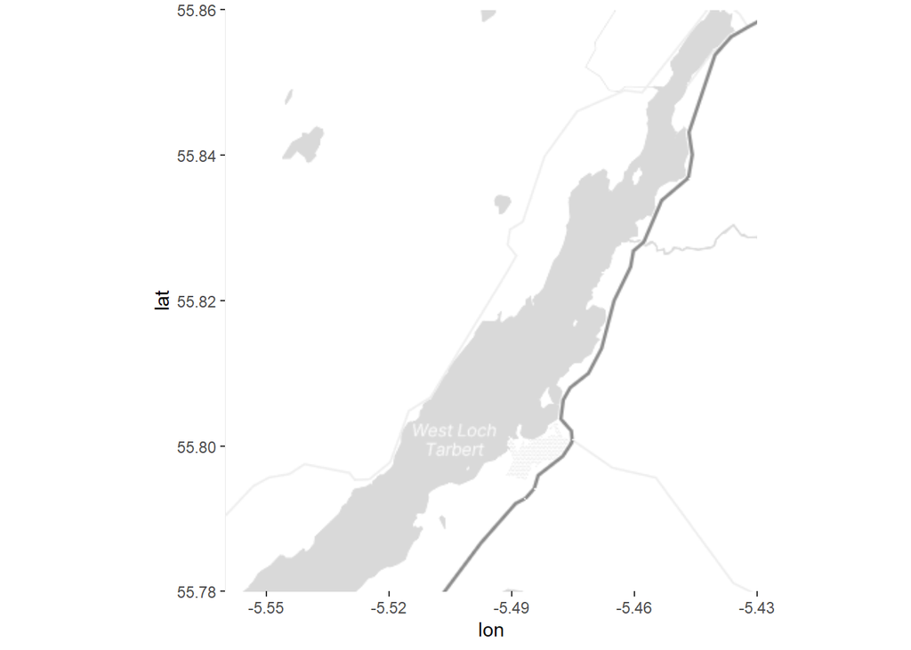

```r
map
```

### Now to add labels

First all the site coordinates in degrees and minutes must be converted to decimal. (All this could be done beforehand in excel and then read into R)

```r
## lats
latone <- 55 + (49.264/60)
lattwo <- 55 + (49.777/60)
latthree <- 55 + (49.351/60)
latfour <- 55 + (49.230/60)
latfive <- 55 + (50.324/60)
latsix <- 55 + (47.787/60)
latseven <- 55 + (48.910/60)

## lons
lonone <- 5 + (28.248/60)
lontwo <- 5 + (28.552/60)
lonthree <- 5 + (28.168/60)
lonfour <- 5 + (29.051/60)
lonfive <- 5 + (27.588/60)
lonsix <- 5 + (31.175/60)
lonseven <- 5 + (29.910/60)

sites <- data.frame("Site"=c("Site 1","Site 2","Site 3","Site 4","Site 5","Site 6","Site 7"),
                    "lat"=c(latone,lattwo,latthree,latfour,latfive,latsix,latseven),
                    "lon"=c(-lonone,-lontwo,-lonthree,-lonfour,-lonfive,-lonsix,-lonseven))

## -longitude's to convert from degrees west to degrees east
```

### Putting everything together

```r
map <- ggmap(get_stadiamap(WLT, zoom = 12, maptype = "stamen_toner_lite")) +
  geom_point(data=sites, aes(x=`lon`, y=`lat`)) +
  geom_text(data=sites,
            aes(x=`lon`,y=`lat`,label=`Site`),
            hjust=c("left","right","left","right","right","right","right"),
            nudge_x = c(0,-0.005,0.005,-0.005,-0.005,-0.005,-0.005),
            nudge_y = c(-0.003,0,0,0,0,0,0)) +
  ylab("Latitude") +
  xlab("Longitude") +
  ggtitle("Sampling Sites on West Loch Tarbert")
```

```
## ℹ © Stadia Maps © Stamen Design © OpenMapTiles © OpenStreetMap contributors.
```

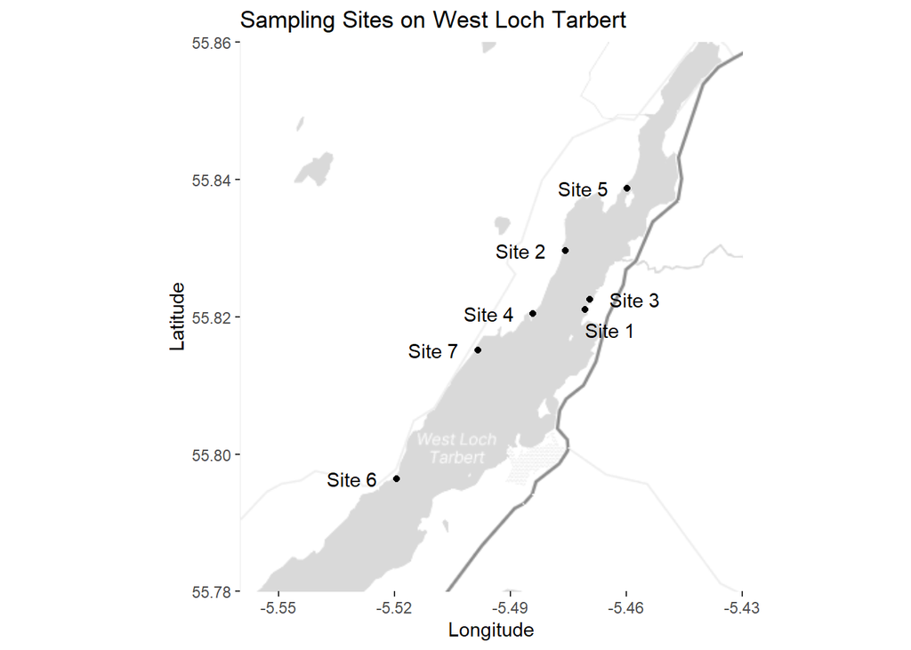

```r
map
```

### Adding a Scalebar

There is loads of code out there for adding complex scale bars to ggmaps. Most of them are out of date with the new versions of R or only work with google map based ggmaps not stadiamaps. In the end I just reverted to manually adding a scale bar with geom_line. The distance between two latitude/longitudes can be determined [here.](https://www.nhc.noaa.gov/gccalc.shtml)

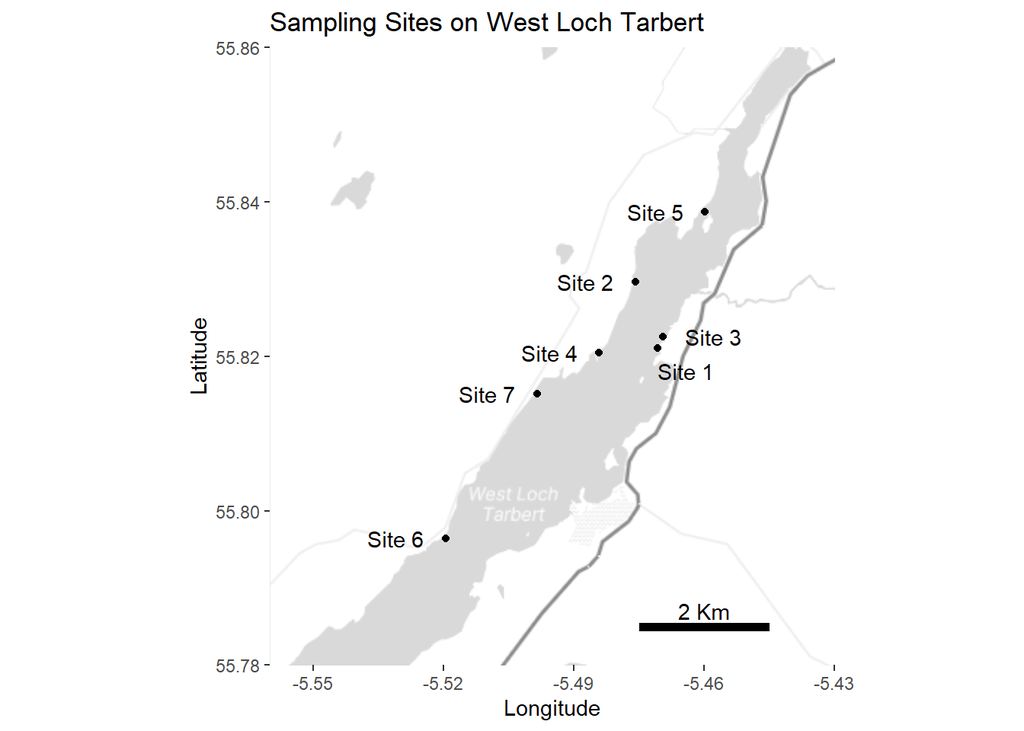

```r
scalebar <- data.frame("lon"=c(-5.445,-5.475), "lat"=c(55.785,55.785))

map + geom_line(data=scalebar, aes(x=lon,y=lat), linewidth=2) +
  annotate("text",x=-5.46, y=55.787, label="2 Km")
```

Thank you to Sarah Salisbury for providing me with links to instruction of how to build maps on R using various packages.